# Tugas ARIMA MPDW

```r
library(readxl)
library(forecast)
library(tseries)
library(TSA)
library(lmtest)
library(MASS)
library(rio)
```

# Import Data

```r
data_raw <- read_excel("C:\\Users\\NI KADEK ARISTA M\\Downloads\\Semester 5\\MPDW\\Data Praktikum MPDW Arista .xlsx",
                        sheet = "Sheet",
                        col_names = FALSE)
# Lihat data awal
head(data_raw)
```

```
## # A tibble: 6 × 4
##   ...1                                                         ...2  ...3  ...4
##   <chr>                                                        <chr> <chr> <chr>
## 1 HARGA TELUR AYAM SEGAR DARI 1 JANUARI 2024-31 DESEMBER  2025 <NA>  <NA>  <NA>
## 2 No                                                           I     II    1
## 3 Komoditas (Rp)                                               Semu… Jawa… Kota…
## 4 01/ 01/ 2024                                                 28.85 27.05 27.65
## 5 02/ 01/ 2024                                                 29.35 26.95 27
## 6 03/ 01/ 2024                                                 29.25 26.8  27
```

```r
# Pembersihan data
data <- data_raw[5:nrow(data_raw), 1:4]

colnames(data) <- c("Tanggal",
                    "Semua_Provinsi",
                    "Jawa_Barat",
                    "Kota_Bogor")

# Ubah tanggal
data$Tanggal <- as.Date(
  data$Tanggal,
  format = "%d/ %m/ %Y"
)

# Ubah variabel harga menjadi numerik
data$Semua_Provinsi <- as.numeric(data$Semua_Provinsi)
data$Jawa_Barat     <- as.numeric(data$Jawa_Barat)
data$Kota_Bogor     <- as.numeric(data$Kota_Bogor)
# Lihat struktur data
str(data)
```

```
## tibble [522 × 4] (S3: tbl_df/tbl/data.frame)
##  $ Tanggal       : Date[1:522], format: "2024-01-02" "2024-01-03" ...
##  $ Semua_Provinsi: num [1:522] 29.4 29.2 29.2 29.1 28.9 ...
##  $ Jawa_Barat    : num [1:522] 26.9 26.8 26.7 26.7 26.4 ...
##  $ Kota_Bogor    : num [1:522] 27 27 27 27 26.2 ...
```

```r
# Statistik deskriptif
summary(data)
```

```
##     Tanggal           Semua_Provinsi    Jawa_Barat      Kota_Bogor
##  Min.   :2024-01-02   Min.   :28.45   Min.   :25.75   Min.   :25.50
##  1st Qu.:2024-07-02   1st Qu.:29.75   1st Qu.:27.25   1st Qu.:27.44
##  Median :2024-12-31   Median :30.30   Median :28.20   Median :28.50
##  Mean   :2024-12-31   Mean   :30.48   Mean   :28.49   Mean   :28.70
##  3rd Qu.:2025-07-01   3rd Qu.:31.24   3rd Qu.:29.60   3rd Qu.:30.00
##  Max.   :2025-12-31   Max.   :33.10   Max.   :32.15   Max.   :32.25
##                                                       NAs    :2
```

## Menentukan Variabel yang Dianalisis

```r
y <- data$Semua_Provinsi

# Cek missing value
sum(is.na(y))
```

```
## [1] 0
```

```r
# Cek panjang data
length(y)
```

```
## [1] 522
```

## Membentuk Time Series

```r
data.ts <- ts(y,
              frequency = 1)

data.ts
```

```
## Time Series:
## Start = 1
## End = 522
## Frequency = 1
##   [1] 29.35 29.25 29.20 29.15 28.95 28.95 28.95 28.90 28.90 28.75 28.75 28.80
##  [13] 28.85 28.95 29.00 29.10 29.05 29.05 29.05 29.05 29.05 29.05 29.05 29.05
##  [25] 29.10 29.10 28.95 29.15 29.20 29.25 29.30 29.10 29.40 29.50 29.80 29.95
##  [37] 29.95 29.95 30.10 30.65 30.85 31.00 31.20 31.40 31.70 31.70 31.85 31.95
##  [49] 32.00 31.95 31.95 32.55 32.55 32.55 32.60 32.65 32.70 32.70 32.65 32.45
##  [61] 32.35 32.25 32.15 32.15 31.80 31.80 31.70 31.75 31.80 31.85 31.85 31.80
##  [73] 31.80 31.80 31.85 31.65 31.50 31.45 31.40 31.20 31.15 31.15 31.10 31.15
##  [85] 31.15 31.25 31.10 31.30 31.35 31.50 31.45 31.45 31.50 31.50 31.45 31.50
##  [97] 31.50 31.50 31.50 31.35 31.35 31.30 31.30 31.30 31.05 31.05 31.00 30.95
## [109] 31.00 30.85 30.90 30.95 30.75 30.80 30.75 30.70 30.70 30.80 30.75 30.75
## [121] 30.85 30.70 30.65 30.60 30.65 30.65 30.55 30.35 30.55 30.50 30.50 30.55
```

[output cut: 33 more lines]

# Eksplorasi Data

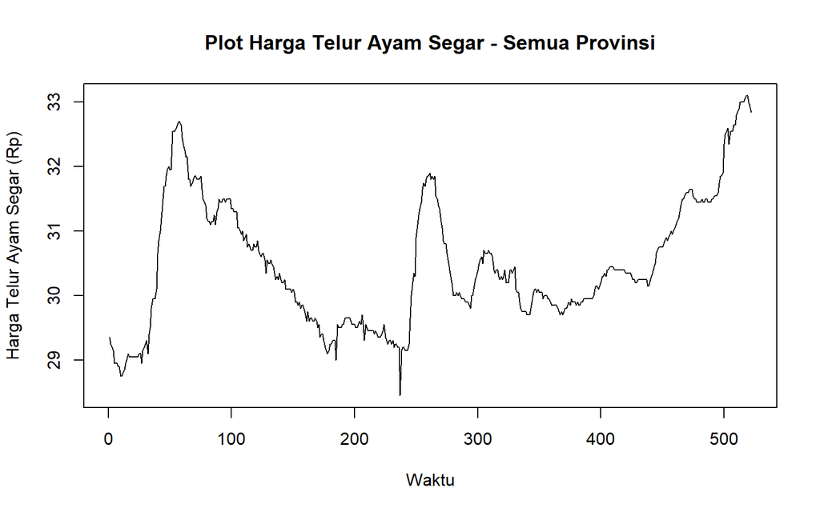

```r
plot.ts(data.ts,
        lty = 1,
        xlab = "Waktu",
        ylab = "Harga Telur Ayam Segar (Rp)",
        main = "Plot Harga Telur Ayam Segar - Semua Provinsi")
```

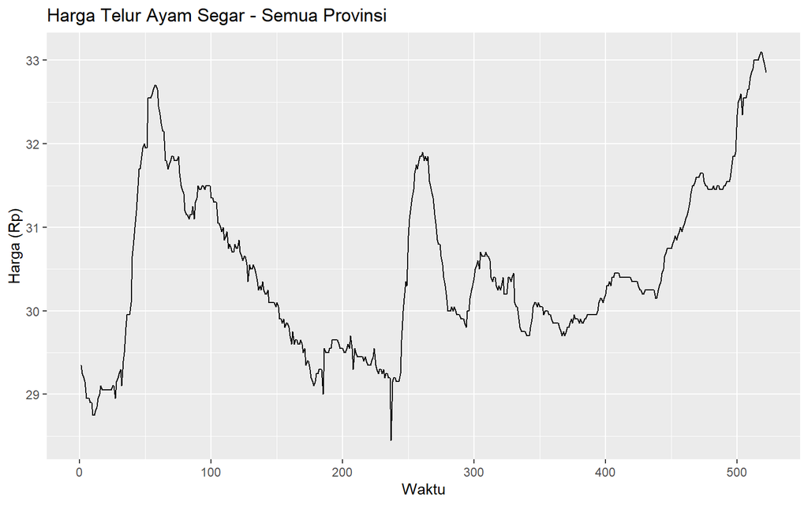

```r
autoplot(data.ts) +
  ggplot2::labs(
    title = "Harga Telur Ayam Segar - Semua Provinsi",
    x = "Waktu",
    y = "Harga (Rp)"
  )
```

## Membagi Data Train dan data Test

```r
n <- length(data.ts)

n_train <- floor(0.8 * n)

n_test <- n - n_train

n_train
```

```
## [1] 417
```

```r
n_test
```

```
## [1] 105
```

```r
train.ts <- data.ts[1:n_train]
test.ts <- data.ts[(n_train + 1):n]
```

Data dibagi menjadi dua bagian, yaitu data training dan data testing. Berdasarkan output, diperoleh 417 observasi sebagai data training dan 105 observasi sebagai data testing. Data training digunakan untuk membangun dan memilih model ARIMA, sedangkan data testing digunakan untuk mengevaluasi kemampuan model dalam melakukan forecasting pada data yang belum digunakan dalam pembentukan model.

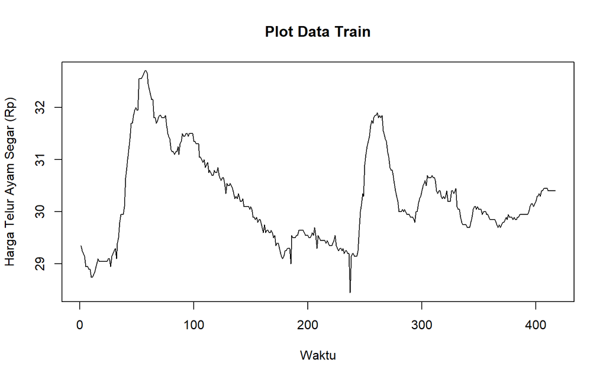

```r
# Plot Data Train
plot.ts(train.ts,
        lty = 1,
        xlab = "Waktu",
        ylab = "Harga Telur Ayam Segar (Rp)",
        main = "Plot Data Train")
```

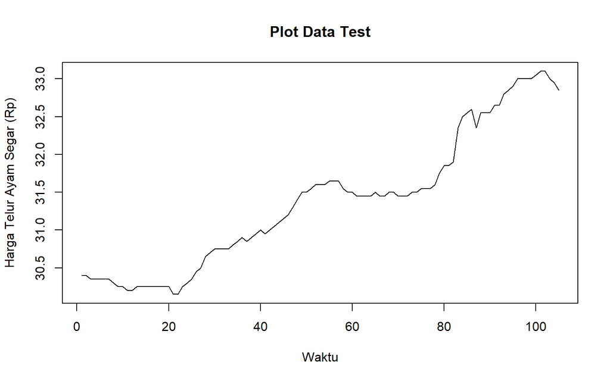

```r
# Plot Data Test
plot.ts(test.ts,
        lty = 1,
        xlab = "Waktu",
        ylab = "Harga Telur Ayam Segar (Rp)",
        main = "Plot Data Test")
```

## Cek Stasioner dalam Rataan

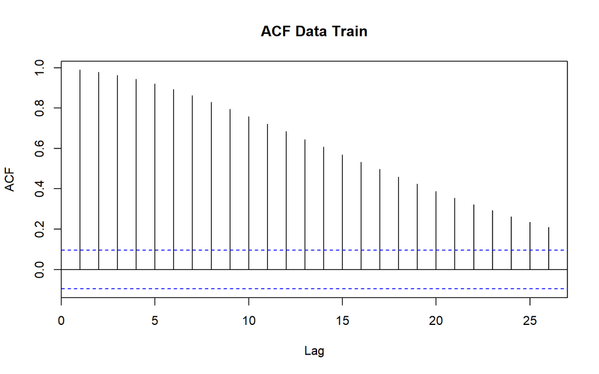

```r
acf(train.ts,
    main = "ACF Data Train")
```

```r
# Uji Augmented Dickey-Fuller
tseries::adf.test(train.ts)
```

```
##
##  Augmented Dickey-Fuller Test
##
## data:  train.ts
## Dickey-Fuller = -4.219, Lag order = 7, p-value = 0.01
## alternative hypothesis: stationary
```

Hipotesis:

H0: Data tidak stasioner dalam rataan H1: Data stasioner dalam rataan

Berdasarkan uji Augmented Dickey-Fuller diperoleh p-value sebesar 0.01. Karena p-value < 0.05, maka H0 ditolak. Dengan demikian, data train dapat dikatakan stasioner dalam rataan.

## Cek Stasioner dalam Ragam

```r
# Cek Stasioner dalam Ragam
library(MASS)

index <- seq_along(train.ts)

bc <- boxcox(train.ts ~ index,
             lambda = seq(-2, 2, by = 0.1))
```

[figure not shown]

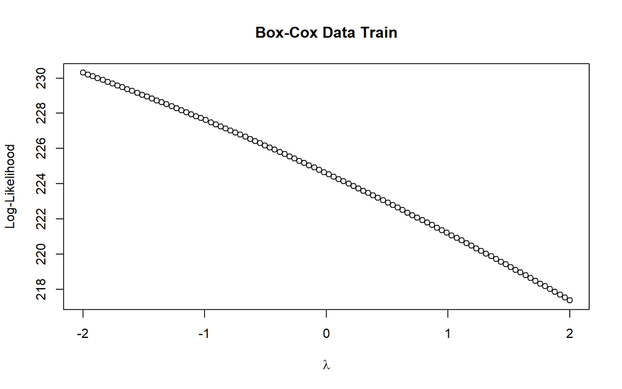

```r
plot(bc,
     main = "Box-Cox Data Train",
     xlab = expression(lambda),
     ylab = "Log-Likelihood")
```

```r
# Lambda optimum
lambda_opt <- bc$x[which.max(bc$y)]

lambda_opt
```

```
## [1] -2
```

Analisis Box-Cox digunakan untuk menentukan transformasi yang sesuai agar ragam data lebih stabil. Nilai lambda optimal yang diperoleh berada pada λ = -2. Nilai tersebut kemudian digunakan sebagai dasar untuk melakukan transformasi Box-Cox terhadap data training.

## Selang kepercayaan Lambda

```r
# Selang kepercayaan 95% untuk lambda
ci_lambda <- bc$x[
  bc$y >
    max(bc$y) - 0.5 * qchisq(0.95, df = 1)
]

ci_lower <- min(ci_lambda)
ci_upper <- max(ci_lambda)

c(
  Batas_Bawah = ci_lower,
  Batas_Atas = ci_upper
)
```

```
## Batas_Bawah  Batas_Atas
##   -2.000000   -1.272727
```

Karena 1 tidak berada dalam selang [-2.000000, -1.272727], maka lambda = 1 berada di luar selang kepercayaan. Artinya, transformasi Box-Cox diperlukan untuk menstabilkan ragam.

# Penanganan Ketidakstasioneran

## Transformasi Box-Cox

```r
# Transformasi Box-Cox
lambda_opt <- -2

train.bc <- (train.ts^lambda_opt - 1) / lambda_opt

head(train.bc)
```

```
## [1] 0.4994196 0.4994156 0.4994136 0.4994116 0.4994034 0.4994034
```

Karena nilai lambda optimal yang diperoleh adalah -2, data training ditransformasi menggunakan transformasi Box-Cox dengan λ = -2. Transformasi ini dilakukan untuk menstabilkan ragam data sebelum proses identifikasi dan pembentukan model ARIMA.

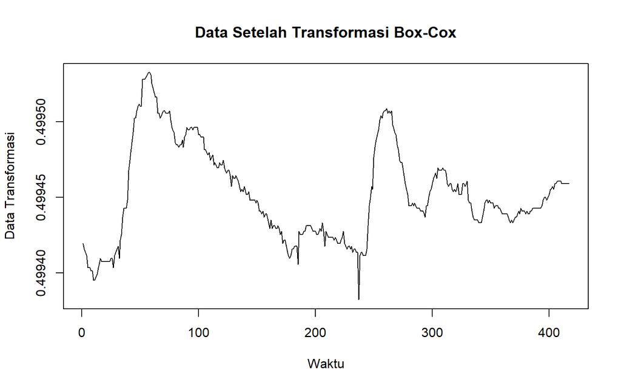

```r
plot.ts(train.bc,
        main = "Data Setelah Transformasi Box-Cox",
        xlab = "Waktu",
        ylab = "Data Transformasi")
```

```r
# Uji ADF setelah transformasi
tseries::adf.test(train.bc)
```

```
##
##  Augmented Dickey-Fuller Test
##
## data:  train.bc
## Dickey-Fuller = -4.2197, Lag order = 7, p-value = 0.01
## alternative hypothesis: stationary
```

Berdasarkan uji Augmented Dickey-Fuller pada data setelah transformasi Box-Cox, diperoleh p-value sebesar 0.01. Karena p-value < 0.05, maka H₀ ditolak. Dengan demikian, data hasil transformasi Box-Cox telah stasioner dalam rataan.

# Identifikasi Model ARIMA

## ACF data setelah transformasi Box-Cox

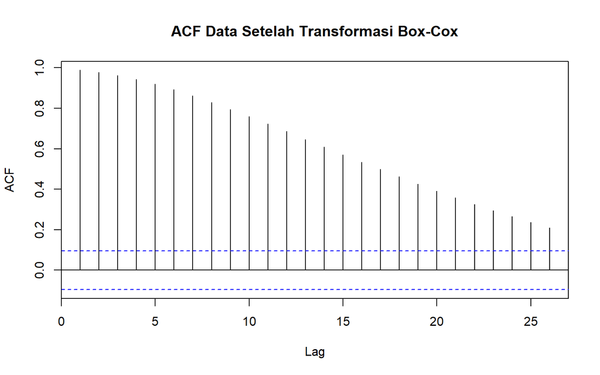

```r
acf(
  train.bc,
  main = "ACF Data Setelah Transformasi Box-Cox"
)
```

Plot ACF digunakan untuk melihat pola korelasi antara nilai pengamatan dengan nilai pada beberapa lag. Pola ACF digunakan sebagai dasar dalam mengidentifikasi kemungkinan orde MA (q) dan membantu menentukan kandidat model ARIMA yang sesuai.

## PACF data setelah transformasi Box-Cox

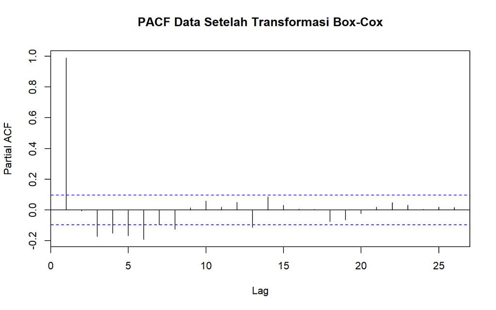

```r
pacf(
  train.bc,
  main = "PACF Data Setelah Transformasi Box-Cox"
)
```

Berdasarkan plot ACF, pola autokorelasi menunjukkan penurunan secara bertahap (tailing off), sedangkan PACF menunjukkan beberapa lag yang signifikan. Pola tersebut mengindikasikan adanya komponen autoregressive (AR). Namun, karena pola ACF dan PACF tidak menunjukkan cut-off yang tegas, penentuan kandidat model selanjutnya dilakukan dengan bantuan EACF.

## EACF data setelah transformasi Box-Cox

```r
TSA::eacf(train.bc)
```

```
## AR/MA
##   0 1 2 3 4 5 6 7 8 9 10 11 12 13
## 0 x x x x x x x x x x x  x  x  x
## 1 o x x x x x x o o x o  x  o  o
## 2 o x o o o o x o o o o  x  o  o
## 3 x o o o o o x o o o o  x  x  o
## 4 x o o o o o x o o o o  x  x  o
## 5 x x x x o o x o o o o  x  x  x
## 6 x x x x o o o o o o o  x  x  o
## 7 x x x x x x o o o o o  o  x  o
```

Berdasarkan hasil EACF, terdapat beberapa pola o yang membentuk area segitiga pada beberapa kombinasi orde AR dan MA. Kandidat model yang dipertimbangkan antara lain ARIMA(2,0,2), ARIMA(2,0,3), ARIMA(3,0,1), ARIMA(3,0,2), ARIMA(4,0,1), dan ARIMA(4,0,2). Kandidat tersebut selanjutnya akan dibandingkan berdasarkan signifikansi parameter serta nilai AIC dan BIC.

# Kandidat model ARIMA dengan d = 0

```r
mod_1 <- arima(train.bc, order = c(1, 0, 0))
mod_2 <- arima(train.bc, order = c(2, 0, 0))
mod_3 <- arima(train.bc, order = c(2, 0, 2))
mod_4 <- arima(train.bc, order = c(2, 0, 3))
mod_5 <- arima(train.bc, order = c(3, 0, 1))
mod_6 <- arima(train.bc, order = c(3, 0, 2))
mod_7 <- arima(train.bc, order = c(4, 0, 1))
mod_8 <- arima(train.bc, order = c(4, 0, 2))
mod_9  <- arima(train.bc, order = c(5, 0, 2))
mod_10 <- arima(train.bc, order = c(4, 0, 3))
mod_11 <- arima(train.bc, order = c(5, 0, 3))
```

Beberapa kandidat model ARIMA dengan d = 0 dibentuk berdasarkan hasil identifikasi ACF, PACF, dan EACF. Penggunaan d = 0 sesuai dengan hasil uji ADF yang menunjukkan bahwa data telah stasioner dalam rataan. Selanjutnya, kandidat model dibandingkan berdasarkan nilai AIC dan BIC serta pemeriksaan diagnostik residual.

```r
# Melihat ringkasan masing-masing model
summary(mod_1)
```

```
##
## Call:
## arima(x = train.bc, order = c(1, 0, 0))
##
## Coefficients:
##          ar1  intercept
##       0.9888     0.4995
## s.e.  0.0064     0.0001
##
## sigma^2 estimated as 1.976e-11:  log likelihood = 4545.42,  aic = -9086.84
##
## Training set error measures:
```

```
##               ME RMSE MAE MPE MAPE
## Training set NaN  NaN NaN NaN  NaN
```

```r
summary(mod_2)
```

```
##
## Call:
## arima(x = train.bc, order = c(2, 0, 0))
##
## Coefficients:
##          ar1     ar2  intercept
##       0.9787  0.0102     0.4995
## s.e.  0.0489  0.0490     0.0001
##
## sigma^2 estimated as 1.975e-11:  log likelihood = 4545.44,  aic = -9084.88
##
## Training set error measures:
```

```
##               ME RMSE MAE MPE MAPE
## Training set NaN  NaN NaN NaN  NaN
```

```r
summary(mod_3)
```

```
##
## Call:
## arima(x = train.bc, order = c(2, 0, 2))
##
## Coefficients:
##          ar1      ar2      ma1     ma2  intercept
##       1.9207  -0.9261  -1.0920  0.2936     0.4995
## s.e.  0.0276   0.0273   0.0576  0.0558     0.0001
##
## sigma^2 estimated as 1.711e-11:  log likelihood = 4575.05,  aic = -9140.09
##
## Training set error measures:
```

```
##               ME RMSE MAE MPE MAPE
## Training set NaN  NaN NaN NaN  NaN
```

```r
summary(mod_4)
```

```
##
## Call:
## arima(x = train.bc, order = c(2, 0, 3))
##
## Coefficients:
##          ar1      ar2      ma1     ma2     ma3  intercept
##       1.8926  -0.8989  -1.0620  0.2060  0.1198     0.4995
## s.e.  0.0360   0.0356   0.0561  0.0656  0.0553     0.0001
##
## sigma^2 estimated as 1.692e-11:  log likelihood = 4577.36,  aic = -9142.72
##
## Training set error measures:
```

```
##               ME RMSE MAE MPE MAPE
## Training set NaN  NaN NaN NaN  NaN
```

```r
summary(mod_5)
```

```
##
## Call:
## arima(x = train.bc, order = c(3, 0, 1))
##
## Coefficients:
##          ar1      ar2      ar3     ma1  intercept
##       1.6746  -0.4387  -0.2417  -0.789     0.4995
## s.e.  0.0616   0.1071   0.0500   0.045     0.0001
##
## sigma^2 estimated as 1.734e-11:  log likelihood = 4572.31,  aic = -9134.63
##
## Training set error measures:
```

```
##               ME RMSE MAE MPE MAPE
## Training set NaN  NaN NaN NaN  NaN
```

```r
summary(mod_6)
```

```
##
## Call:
## arima(x = train.bc, order = c(3, 0, 2))
##
## Coefficients:
##           ar1     ar2     ar3     ma1     ma2  intercept
##       -0.6151  0.6100  0.9661  1.6030  1.0000     0.4994
## s.e.   0.0139  0.0124  0.0131  0.0111  0.0129     0.0001
##
## sigma^2 estimated as 1.9e-11:  log likelihood = 4551.39,  aic = -9090.78
##
## Training set error measures:
```

```
##               ME RMSE MAE MPE MAPE
## Training set NaN  NaN NaN NaN  NaN
```

```r
summary(mod_7)
```

```
##
## Call:
## arima(x = train.bc, order = c(4, 0, 1))
##
## Coefficients:
##          ar1      ar2      ar3      ar4      ma1  intercept
##       1.6095  -0.4227  -0.0971  -0.0966  -0.7410     0.4995
## s.e.  0.0729   0.1069   0.0960   0.0552   0.0567     0.0001
##
## sigma^2 estimated as 1.722e-11:  log likelihood = 4573.78,  aic = -9135.55
##
## Training set error measures:
```

```
##               ME RMSE MAE MPE MAPE
## Training set NaN  NaN NaN NaN  NaN
```

```r
summary(mod_8)
```

```
##
## Call:
## arima(x = train.bc, order = c(4, 0, 2))
##
## Coefficients:
##          ar1      ar2     ar3      ar4      ma1     ma2  intercept
##       2.3083  -1.7188  0.4078  -0.0016  -1.4673  0.6742     0.4995
## s.e.  0.1068   0.2116  0.1541   0.0636   0.0951  0.0951     0.0001
##
## sigma^2 estimated as 1.679e-11:  log likelihood = 4578.88,  aic = -9143.76
##
## Training set error measures:
```

```
##               ME RMSE MAE MPE MAPE
## Training set NaN  NaN NaN NaN  NaN
```

```r
summary(mod_9)
```

```
##
## Call:
## arima(x = train.bc, order = c(5, 0, 2))
##
## Coefficients:
##          ar1      ar2     ar3     ar4      ar5      ma1     ma2  intercept
##       2.2212  -1.5952  0.2768  0.2127  -0.1213  -1.3800  0.6510     0.4995
## s.e.  0.1533   0.2665  0.1592  0.1277   0.0636   0.1473  0.1225     0.0001
##
## sigma^2 estimated as 1.665e-11:  log likelihood = 4580.63,  aic = -9145.25
##
## Training set error measures:
```

```
##               ME RMSE MAE MPE MAPE
## Training set NaN  NaN NaN NaN  NaN
```

```r
summary(mod_10)
```

```
##
## Call:
## arima(x = train.bc, order = c(4, 0, 3))
##
## Coefficients:
##          ar1     ar2      ar3     ar4      ma1      ma2     ma3  intercept
##       1.3247  0.5500  -1.2795  0.3962  -0.4825  -0.7715  0.6659     0.4995
## s.e.  0.1088  0.1362   0.1198  0.1098   0.0916   0.0596  0.0947     0.0001
##
## sigma^2 estimated as 1.678e-11:  log likelihood = 4578.96,  aic = -9141.92
##
## Training set error measures:
```

```
##               ME RMSE MAE MPE MAPE
## Training set NaN  NaN NaN NaN  NaN
```

```r
summary(mod_11)
```

```
##
## Call:
## arima(x = train.bc, order = c(5, 0, 3))
##
## Coefficients:
##          ar1     ar2     ar3      ar4      ar5     ma1     ma2      ma3
##       0.4907  0.5486  0.8822  -0.6784  -0.2618  0.4096  0.0645  -0.7838
## s.e.  0.0617  0.0438  0.0279   0.0546   0.0496  0.0466  0.0554   0.0463
##       intercept
##          0.4995
## s.e.     0.0001
##
## sigma^2 estimated as 1.686e-11:  log likelihood = 4576.31,  aic = -9134.62
##
## Training set error measures:
```

```
##               ME RMSE MAE MPE MAPE
## Training set NaN  NaN NaN NaN  NaN
```

## Perbandingan AIC dan BIC

```r
# Perbandingan AIC dan BIC
model_comparison <- data.frame(
  Model = c(
    "ARIMA(1,0,0)",
    "ARIMA(2,0,0)",
    "ARIMA(2,0,2)",
    "ARIMA(2,0,3)",
    "ARIMA(3,0,1)",
    "ARIMA(3,0,2)",
    "ARIMA(4,0,1)",
    "ARIMA(4,0,2)",
    "ARIMA(5,0,2)",
    "ARIMA(4,0,3)",
    "ARIMA(5,0,3)"
  ),
  AIC = c(
    AIC(mod_1),
    AIC(mod_2),
    AIC(mod_3),
    AIC(mod_4),
    AIC(mod_5),
    AIC(mod_6),
    AIC(mod_7),
    AIC(mod_8),
    AIC(mod_9),
    AIC(mod_10),
    AIC(mod_11)
  ),
  BIC = c(
    BIC(mod_1),
    BIC(mod_2),
    BIC(mod_3),
    BIC(mod_4),
    BIC(mod_5),
    BIC(mod_6),
    BIC(mod_7),
    BIC(mod_8),
    BIC(mod_9),
    BIC(mod_10),
    BIC(mod_11)
  )
)

model_comparison
```

```
##           Model       AIC       BIC
## 1  ARIMA(1,0,0) -9084.836 -9072.737
## 2  ARIMA(2,0,0) -9082.878 -9066.745
## 3  ARIMA(2,0,2) -9138.092 -9113.893
## 4  ARIMA(2,0,3) -9140.716 -9112.485
## 5  ARIMA(3,0,1) -9132.627 -9108.429
## 6  ARIMA(3,0,2) -9088.784 -9060.553
## 7  ARIMA(4,0,1) -9133.552 -9105.321
## 8  ARIMA(4,0,2) -9141.760 -9109.495
## 9  ARIMA(5,0,2) -9143.253 -9106.955
## 10 ARIMA(4,0,3) -9139.918 -9103.620
## 11 ARIMA(5,0,3) -9132.620 -9092.289
```

# Overfitting Model

## Menambah Orde AR

```r
# Menambah orde AR dari model ARIMA(5,0,2)
mod_over_ar <- arima(train.bc,
                     order = c(6, 0, 2))

# Melihat ringkasan model
summary(mod_over_ar)
```

```
##
## Call:
## arima(x = train.bc, order = c(6, 0, 2))
##
## Coefficients:
##          ar1      ar2     ar3     ar4     ar5      ar6      ma1     ma2
##       1.9320  -1.2074  0.2256  0.1159  0.0582  -0.1341  -1.0936  0.5153
## s.e.  0.1913   0.2860  0.1410  0.1238  0.1219   0.0766   0.1898  0.1211
##       intercept
##          0.4995
## s.e.     0.0001
##
## sigma^2 estimated as 1.657e-11:  log likelihood = 4581.67,  aic = -9145.34
##
## Training set error measures:
```

```
##               ME RMSE MAE MPE MAPE
## Training set NaN  NaN NaN NaN  NaN
```

Output: AIC = -9145,34

Nilai AIC ARIMA(6,0,2) lebih kecil daripada ARIMA(5,0,2). Namun, penambahan orde tidak hanya dinilai berdasarkan AIC, tetapi juga berdasarkan signifikansi parameter dan diagnostik residual.

## Menambah Orde MA

```r
# Menambah orde MA dari model ARIMA(5,0,2)
mod_over_ma <- arima(train.bc,
                     order = c(5, 0, 3))

# Melihat ringkasan model
summary(mod_over_ma)
```

```
##
## Call:
## arima(x = train.bc, order = c(5, 0, 3))
##
## Coefficients:
##          ar1     ar2     ar3      ar4      ar5     ma1     ma2      ma3
##       0.4907  0.5486  0.8822  -0.6784  -0.2618  0.4096  0.0645  -0.7838
## s.e.  0.0617  0.0438  0.0279   0.0546   0.0496  0.0466  0.0554   0.0463
##       intercept
##          0.4995
## s.e.     0.0001
##
## sigma^2 estimated as 1.686e-11:  log likelihood = 4576.31,  aic = -9134.62
##
## Training set error measures:
```

```
##               ME RMSE MAE MPE MAPE
## Training set NaN  NaN NaN NaN  NaN
```

## Uji Signifikasi Parameter

```r
library(lmtest)

# Model awal
coeftest(mod_9)
```

```
##
## z test of coefficients:
##
##              Estimate  Std. Error   z value  Pr(>|z|)
## ar1        2.2212e+00  1.5326e-01   14.4927 < 2.2e-16 ***
## ar2       -1.5952e+00  2.6653e-01   -5.9848 2.167e-09 ***
## ar3        2.7677e-01  1.5921e-01    1.7383   0.08216 .
## ar4        2.1269e-01  1.2770e-01    1.6656   0.09580 .
## ar5       -1.2134e-01  6.3641e-02   -1.9067   0.05656 .
## ma1       -1.3800e+00  1.4735e-01   -9.3657 < 2.2e-16 ***
## ma2        6.5098e-01  1.2251e-01    5.3136 1.075e-07 ***
## intercept  4.9945e-01  5.0325e-05 9924.4910 < 2.2e-16 ***
## ---
## Signif. codes:  0 '***' 0.001 '**' 0.01 '*' 0.05 '.' 0.1 ' ' 1
```

```r
# Model dengan penambahan AR
coeftest(mod_over_ar)
```

```
##
## z test of coefficients:
##
##              Estimate  Std. Error   z value  Pr(>|z|)
## ar1        1.9320e+00  1.9131e-01   10.0986 < 2.2e-16 ***
## ar2       -1.2074e+00  2.8599e-01   -4.2219 2.422e-05 ***
## ar3        2.2564e-01  1.4103e-01    1.5999   0.10962
## ar4        1.1585e-01  1.2378e-01    0.9360   0.34928
## ar5        5.8184e-02  1.2194e-01    0.4771   0.63326
## ar6       -1.3408e-01  7.6644e-02   -1.7493   0.08023 .
## ma1       -1.0936e+00  1.8980e-01   -5.7619 8.320e-09 ***
## ma2        5.1532e-01  1.2111e-01    4.2551 2.090e-05 ***
## intercept  4.9945e-01  5.0083e-05 9972.4702 < 2.2e-16 ***
## ---
## Signif. codes:  0 '***' 0.001 '**' 0.01 '*' 0.05 '.' 0.1 ' ' 1
```

```r
# Model dengan penambahan MA
coeftest(mod_over_ma)
```

```
##
## z test of coefficients:
##
##              Estimate  Std. Error   z value  Pr(>|z|)
## ar1        4.9068e-01  6.1690e-02    7.9540 1.805e-15 ***
## ar2        5.4856e-01  4.3826e-02   12.5170 < 2.2e-16 ***
## ar3        8.8223e-01  2.7891e-02   31.6317 < 2.2e-16 ***
## ar4       -6.7837e-01  5.4616e-02  -12.4208 < 2.2e-16 ***
## ar5       -2.6181e-01  4.9632e-02   -5.2750 1.328e-07 ***
## ma1        4.0963e-01  4.6554e-02    8.7990 < 2.2e-16 ***
## ma2        6.4475e-02  5.5372e-02    1.1644    0.2443
## ma3       -7.8382e-01  4.6318e-02  -16.9226 < 2.2e-16 ***
## intercept  4.9945e-01  5.0467e-05 9896.6886 < 2.2e-16 ***
## ---
## Signif. codes:  0 '***' 0.001 '**' 0.01 '*' 0.05 '.' 0.1 ' ' 1
```

## Perbandingan AIC dan BIC

```r
model_overfitting <- data.frame(
  Model = c("ARIMA(5,0,2)",
            "ARIMA(6,0,2)",
            "ARIMA(5,0,3)"),
  AIC = c(AIC(mod_9),
          AIC(mod_over_ar),
          AIC(mod_over_ma)),
  BIC = c(BIC(mod_9),
          BIC(mod_over_ar),
          BIC(mod_over_ma))
)

model_overfitting
```

```
##          Model       AIC       BIC
## 1 ARIMA(5,0,2) -9143.253 -9106.955
## 2 ARIMA(6,0,2) -9143.342 -9103.011
## 3 ARIMA(5,0,3) -9132.620 -9092.289
```

## Uji Ljung-Box Residual

```r
# Ljung-Box ARIMA(6,0,2)
Box.test <- Box.test(residuals(mod_over_ar),
                     lag = 20,
                     type = "Ljung-Box")
Box.test
```

```
##
##  Box-Ljung test
##
## data:  residuals(mod_over_ar)
## X-squared = 21.753, df = 20, p-value = 0.354
```

```r
# Ljung-Box ARIMA(5,0,3)
Box.test <- Box.test(residuals(mod_over_ma),
                     lag = 20,
                     type = "Ljung-Box")
Box.test
```

```
##
##  Box-Ljung test
##
## data:  residuals(mod_over_ma)
## X-squared = 42.62, df = 20, p-value = 0.002294
```

# Model Final

```r
model_akhir <- forecast::Arima(train.bc,
                               order = c(5, 0, 2))

model_akhir
```

```
## Series: train.bc
## ARIMA(5,0,2) with non-zero mean
##
## Coefficients:
##          ar1      ar2     ar3     ar4      ar5      ma1     ma2    mean
##       2.2212  -1.5952  0.2768  0.2127  -0.1213  -1.3800  0.6510  0.4995
## s.e.  0.1533   0.2665  0.1592  0.1277   0.0636   0.1473  0.1225  0.0001
##
## sigma^2 = 1.697e-11:  log likelihood = 4580.63
## AIC=-9143.25   AICc=-9142.81   BIC=-9106.95
```

```r
hasil_forecast <- forecast::forecast(model_akhir,
                                    h = length(test.ts))

hasil_forecast
```

```
##     Point Forecast     Lo 80     Hi 80     Lo 95     Hi 95
## 418      0.4994585 0.4994533 0.4994638 0.4994505 0.4994666
## 419      0.4994584 0.4994515 0.4994653 0.4994479 0.4994690
## 420      0.4994583 0.4994499 0.4994668 0.4994454 0.4994713
## 421      0.4994583 0.4994484 0.4994683 0.4994431 0.4994735
## 422      0.4994583 0.4994466 0.4994699 0.4994404 0.4994761
## 423      0.4994581 0.4994445 0.4994717 0.4994373 0.4994789
## 424      0.4994579 0.4994423 0.4994736 0.4994340 0.4994818
## 425      0.4994577 0.4994401 0.4994754 0.4994308 0.4994847
## 426      0.4994575 0.4994380 0.4994770 0.4994277 0.4994874
## 427      0.4994573 0.4994360 0.4994786 0.4994248 0.4994899
## 428      0.4994571 0.4994341 0.4994801 0.4994220 0.4994922
## 429      0.4994569 0.4994323 0.4994814 0.4994193 0.4994944
## 430      0.4994566 0.4994306 0.4994827 0.4994169 0.4994964
## 431      0.4994564 0.4994290 0.4994838 0.4994145 0.4994983
```

[output cut: 91 more lines]

# Forecasting

## Melakukan forecasting

```r
library(forecast)

# Forecast sebanyak periode data testing
hasil_forecast <- forecast::forecast(
  model_akhir,
  h = length(test.ts)
)

hasil_forecast
```

```
##     Point Forecast     Lo 80     Hi 80     Lo 95     Hi 95
## 418      0.4994585 0.4994533 0.4994638 0.4994505 0.4994666
## 419      0.4994584 0.4994515 0.4994653 0.4994479 0.4994690
## 420      0.4994583 0.4994499 0.4994668 0.4994454 0.4994713
## 421      0.4994583 0.4994484 0.4994683 0.4994431 0.4994735
## 422      0.4994583 0.4994466 0.4994699 0.4994404 0.4994761
## 423      0.4994581 0.4994445 0.4994717 0.4994373 0.4994789
## 424      0.4994579 0.4994423 0.4994736 0.4994340 0.4994818
## 425      0.4994577 0.4994401 0.4994754 0.4994308 0.4994847
## 426      0.4994575 0.4994380 0.4994770 0.4994277 0.4994874
## 427      0.4994573 0.4994360 0.4994786 0.4994248 0.4994899
## 428      0.4994571 0.4994341 0.4994801 0.4994220 0.4994922
## 429      0.4994569 0.4994323 0.4994814 0.4994193 0.4994944
## 430      0.4994566 0.4994306 0.4994827 0.4994169 0.4994964
## 431      0.4994564 0.4994290 0.4994838 0.4994145 0.4994983
```

[output cut: 91 more lines]

Output menunjukkan bahwa nilai hasil forecast pada skala transformasi berada di sekitar 0,49945 dan secara perlahan menurun. Selain point forecast, output juga menyediakan batas bawah dan batas atas untuk interval prediksi 80% dan 95%.

## Mengembalikan hasil forecast ke skala asli

Karena model dibangun menggunakan data hasil transformasi Box-Cox, hasil forecast perlu dikembalikan ke skala asli menggunakan inverse Box-Cox dengan λ = -2.

```r
lambda_opt <- -2

forecast_asli <- InvBoxCox(
  hasil_forecast$mean,
  lambda = lambda_opt
)

head(forecast_asli)
```

```
## Time Series:
## Start = 418
## End = 423
## Frequency = 1
## [1] 30.38820 30.38416 30.38249 30.38198 30.37988 30.37614
```

## Membandingkan aktual dan forecast

```r
hasil_ramalan <- data.frame(
  Aktual = as.numeric(test.ts),
  Forecast = as.numeric(forecast_asli)
)

head(hasil_ramalan)
```

```
##   Aktual Forecast
## 1  30.40 30.38820
## 2  30.40 30.38416
## 3  30.35 30.38249
## 4  30.35 30.38198
## 5  30.35 30.37988
## 6  30.35 30.37614
```

Nilai forecast berada cukup dekat dengan nilai aktual pada beberapa observasi awal. Plot aktual dan forecast digunakan untuk melihat secara visual kedekatan pola hasil ramalan terhadap data aktual.

[figure not shown]

```r
plot(test.ts,
     type = "l",
     main = "Perbandingan Data Aktual dan Hasil Forecasting",
     xlab = "Periode",
     ylab = "Nilai")

lines(forecast_asli,
      lty = 2)

legend("topleft",
       legend = c("Aktual", "Forecast"),
       lty = c(1, 2))
```

# Evaluasi Forecasting

## Membuat tabel aktual dan forecasting

```r
hasil_ramalan <- data.frame(
  Aktual = as.numeric(test.ts),
  Forecast = as.numeric(forecast_asli)
)

head(hasil_ramalan)
```

```
##   Aktual Forecast
## 1  30.40 30.38820
## 2  30.40 30.38416
## 3  30.35 30.38249
## 4  30.35 30.38198
## 5  30.35 30.37988
## 6  30.35 30.37614
```

Nilai forecast berada cukup dekat dengan nilai aktual pada beberapa observasi awal. Plot aktual dan forecast digunakan untuk melihat secara visual kedekatan pola hasil ramalan terhadap data aktual.

## Menghitung MAE

```r
MAE <- mean(abs(hasil_ramalan$Aktual - hasil_ramalan$Forecast))

MAE
```

```
## [1] 1.162981
```

Nilai MAE sebesar 1,162981 menunjukkan rata-rata besarnya kesalahan absolut antara nilai aktual dan hasil forecast adalah sekitar 1,16 satuan.

## Menghitung RMSE

```r
RMSE <- sqrt(mean(
  (hasil_ramalan$Aktual - hasil_ramalan$Forecast)^2
))

RMSE
```

```
## [1] 1.472466
```

Nilai RMSE sebesar 1,472466 menunjukkan besarnya kesalahan prediksi dengan memberikan penalti yang lebih besar terhadap kesalahan yang lebih besar.

## Menghitung MAPE

```r
MAPE <- mean(
  abs((hasil_ramalan$Aktual - hasil_ramalan$Forecast) /
        hasil_ramalan$Aktual)
) * 100

MAPE
```

```
## [1] 3.628052
```

Nilai MAPE sebesar 3,628052% menunjukkan bahwa rata-rata kesalahan absolut hasil forecasting relatif terhadap nilai aktual adalah sekitar 3,63%.

## Menampilkan semua ukuran akurasi

```r
akurasi <- data.frame(
  MAE = MAE,
  RMSE = RMSE,
  MAPE = MAPE
)

akurasi
```

```
##        MAE     RMSE     MAPE
## 1 1.162981 1.472466 3.628052
```

Ketiga ukuran tersebut digunakan untuk menggambarkan besarnya kesalahan forecasting pada data testing.

## Plot Aktual vs Forecasting

[figure not shown]

```r
plot(test.ts,
     type = "l",
     main = "Aktual vs Forecast",
     xlab = "Periode",
     ylab = "Nilai")

lines(forecast_asli,
      lty = 2)

legend("topleft",
       legend = c("Aktual", "Forecast"),
       lty = c(1, 2))
```

Plot ini digunakan untuk melihat secara visual apakah pola hasil ramalan mengikuti pergerakan data aktual. Semakin dekat garis forecast terhadap garis aktual, semakin kecil perbedaan visual antara hasil ramalan dan pengamatan aktual.

# Kesimpulan

Berdasarkan analisis data deret waktu, data yang digunakan terdiri dari 522 observasi dan tidak memiliki missing value pada variabel yang dianalisis. Setelah dilakukan pemeriksaan stasioneritas dan transformasi Box-Cox dengan nilai lambda optimal -2, data memenuhi kondisi stasioner dalam mean sehingga dapat dilanjutkan ke pemodelan ARIMA.